# Lab 1: R for GIS – Fundamentals

## 1. Download lab1 Data and Prepare R Working Directory

Create a folder on the C drive named Geog4254. Download lab1.zip from the Canvas website and place it in the C:/Geog4254 folder. Unzip it so you have a folder named lab1 within C:/Geog4254. In the lab1 folder, you’ll find a shapefile named y2010_51_pophu.shp.

## 2. Start RStudio and Set Working Directory

2.1 Open RStudio.

2.2 Go to the Session menu, select Set Working Directory, and then choose Choose Directory

2.3 In the file dialog, navigate to C:/Geog4254/lab1 and click Open.

## 3. Install foundational R geospatial packages

Simple Features (`sf`) is primarily used for vector data, and `terra` is primarily used for raster data.The dplyr library in R provides a suite of functions for efficient data manipulation, enabling intuitive and readable workflows for filtering, transforming, and summarizing data. # Uncomment and run the following lines in your R console to install the required packages

# # install.packages(‘sf’)

# # install.packages(‘terra’)

# # install.packages(‘dplyr’)

## 4. Load R libraries

Students may copy the lines in the gray block directly to the R console to load the necessary libraries. Alternatively, you can start a new script in RStudio, paste these lines into the script, and run them from there. Loading these libraries is essential to ensure that you have the necessary tools for handling spatial data in this lab.

```r
library(sf)
library(terra)
library(dplyr)
```

## 1.1 Working with Shapefile

R has a number of libraries for handling shapefiles. In this lab, we’ll focus on the `sf` library. Use the `st_read()` function to read a shapefile. R imports the shapefile as a data frame, named `pophu` here.

```r
pophu <- st_read('y2010_51_pophu.shp')
```

*Some useful functions for handling R data frames*

Display the first n rows present in the input data frame:

```r
head(pophu)
```

```
## Simple feature collection with 6 features and 9 fields
## Geometry type: MULTIPOLYGON
## Dimension:     XY
## Bounding box:  xmin: -80.32668 ymin: 37.22773 xmax: -79.84163 ymax: 37.49369
## Geodetic CRS:  NAD83
##   STATEFP10 COUNTYFP10 TRACTCE10 BLOCKCE       BLOCKID10 PARTFLG HOUSING10
## 1        51        019    030602    2047 510190306022047       N         0
## 2        51        045    050100    3028 510450501003028       N       145
## 3        51        045    050100    3046 510450501003046       N         0
## 4        51        045    050100    3030 510450501003030       N         0
## 5        51        045    050100    2328 510450501002328       N         0
## 6        51        045    050100    2100 510450501002100       N         0
##   POP10 ID                       geometry
## 1     0  1 MULTIPOLYGON (((-79.84413 3...
## 2   326  2 MULTIPOLYGON (((-80.10891 3...
## 3     0  3 MULTIPOLYGON (((-80.20565 3...
## 4     0  4 MULTIPOLYGON (((-80.18561 3...
## 5     0  5 MULTIPOLYGON (((-80.32459 3...
## 6     0  6 MULTIPOLYGON (((-80.29813 3...
```

*A brief explanation of the variables in the data frame:*

*STATEFP10: A character variable representing the state FIPS code, uniquely identifying each state.

*COUNTYFP10: A character variable representing the county FIPS code, uniquely identifying each county within a state.

*TRACTCE10: A character variable representing the census tract code, uniquely identifying each tract within a county.

*BLOCKCE: A character variable representing the block code, uniquely identifying each block within a tract.

*BLOCKID10: A character variable representing the complete block identifier, concatenating state, county, tract, and block codes.

*PARTFLG: A character variable indicating whether the block is partially within a specified boundary.

*HOUSING10: A numeric variable indicating the number of housing units in 2010 for each block.

*POP10: A numeric variable indicating the population in 2010 for each block.

*ID: A numeric variable providing a unique identifier for each record.

*geometry: A spatial variable of type MULTIPOLYGON representing the geographical boundaries of each block.

*Display summary statistics of the data frame:*

```r
summary(pophu)
```

```
##   STATEFP10          COUNTYFP10         TRACTCE10           BLOCKCE
##  Length:16565       Length:16565       Length:16565       Length:16565
##  Class :character   Class :character   Class :character   Class :character
##  Mode  :character   Mode  :character   Mode  :character   Mode  :character
##
##
##
##   BLOCKID10           PARTFLG            HOUSING10          POP10
##  Length:16565       Length:16565       Min.   :  0.00   Min.   :   0.00
##  Class :character   Class :character   1st Qu.:  0.00   1st Qu.:   0.00
##  Mode  :character   Mode  :character   Median :  1.00   Median :   2.00
##                                        Mean   : 10.36   Mean   :  23.09
##                                        3rd Qu.: 10.00   3rd Qu.:  21.00
##                                        Max.   :580.00   Max.   :5322.00
##        ID                 geometry
##  Min.   :    1   MULTIPOLYGON :16565
##  1st Qu.: 4142   epsg:4269    :    0
##  Median : 8283   +proj=long...:    0
##  Mean   : 8283
##  3rd Qu.:12424
##  Max.   :16565
```

*Display dimension of the data frame:*

```r
dim(pophu)
```

```
## [1] 16565    10
```

*Select a column and assign it to a new variable*

In R, the $ sign is used to extract a specific column (or variable) from a data frame. The following lines extract the column named POP10 from the pophu data frame and then assign it to a new variable a.

```r
a <- pophu$POP10
```

*Select rows and columns from a data frame*

```r
pophu[1:5, ]    # This selects the first 5 rows of the pophu data frame
```

```
## Simple feature collection with 5 features and 9 fields
## Geometry type: MULTIPOLYGON
## Dimension:     XY
## Bounding box:  xmin: -80.32668 ymin: 37.22773 xmax: -79.84163 ymax: 37.49369
## Geodetic CRS:  NAD83
##   STATEFP10 COUNTYFP10 TRACTCE10 BLOCKCE       BLOCKID10 PARTFLG HOUSING10
## 1        51        019    030602    2047 510190306022047       N         0
## 2        51        045    050100    3028 510450501003028       N       145
## 3        51        045    050100    3046 510450501003046       N         0
## 4        51        045    050100    3030 510450501003030       N         0
## 5        51        045    050100    2328 510450501002328       N         0
##   POP10 ID                       geometry
## 1     0  1 MULTIPOLYGON (((-79.84413 3...
## 2   326  2 MULTIPOLYGON (((-80.10891 3...
## 3     0  3 MULTIPOLYGON (((-80.20565 3...
## 4     0  4 MULTIPOLYGON (((-80.18561 3...
## 5     0  5 MULTIPOLYGON (((-80.32459 3...
```

```r
pophu[, 1:3]    # This selects the first 3 columns of the pophu data frame.
```

```
## Simple feature collection with 16565 features and 3 fields
## Geometry type: MULTIPOLYGON
## Dimension:     XY
## Bounding box:  xmin: -81.01449 ymin: 36.879 xmax: -79.83963 ymax: 37.66029
## Geodetic CRS:  NAD83
## First 10 features:
##    STATEFP10 COUNTYFP10 TRACTCE10                       geometry
## 1         51        019    030602 MULTIPOLYGON (((-79.84413 3...
## 2         51        045    050100 MULTIPOLYGON (((-80.10891 3...
## 3         51        045    050100 MULTIPOLYGON (((-80.20565 3...
## 4         51        045    050100 MULTIPOLYGON (((-80.18561 3...
## 5         51        045    050100 MULTIPOLYGON (((-80.32459 3...
## 6         51        045    050100 MULTIPOLYGON (((-80.29813 3...
## 7         51        045    050100 MULTIPOLYGON (((-80.27739 3...
## 8         51        045    050100 MULTIPOLYGON (((-80.23252 3...
## 9         51        045    050100 MULTIPOLYGON (((-80.18933 3...
## 10        51        045    050100 MULTIPOLYGON (((-80.15552 3...
```

```r
pophu[1:5, 1:3] # This selects the first 5 rows and the first 3 columns of the pophu data frame.
```

```
## Simple feature collection with 5 features and 3 fields
## Geometry type: MULTIPOLYGON
## Dimension:     XY
## Bounding box:  xmin: -80.32668 ymin: 37.22773 xmax: -79.84163 ymax: 37.49369
## Geodetic CRS:  NAD83
##   STATEFP10 COUNTYFP10 TRACTCE10                       geometry
## 1        51        019    030602 MULTIPOLYGON (((-79.84413 3...
## 2        51        045    050100 MULTIPOLYGON (((-80.10891 3...
## 3        51        045    050100 MULTIPOLYGON (((-80.20565 3...
## 4        51        045    050100 MULTIPOLYGON (((-80.18561 3...
## 5        51        045    050100 MULTIPOLYGON (((-80.32459 3...
```

```r
pophu[, c("HOUSING10", "POP10")] # select variables by column names
```

```
## Simple feature collection with 16565 features and 2 fields
## Geometry type: MULTIPOLYGON
## Dimension:     XY
## Bounding box:  xmin: -81.01449 ymin: 36.879 xmax: -79.83963 ymax: 37.66029
## Geodetic CRS:  NAD83
## First 10 features:
##    HOUSING10 POP10                       geometry
## 1          0     0 MULTIPOLYGON (((-79.84413 3...
## 2        145   326 MULTIPOLYGON (((-80.10891 3...
## 3          0     0 MULTIPOLYGON (((-80.20565 3...
## 4          0     0 MULTIPOLYGON (((-80.18561 3...
## 5          0     0 MULTIPOLYGON (((-80.32459 3...
## 6          0     0 MULTIPOLYGON (((-80.29813 3...
## 7          0     0 MULTIPOLYGON (((-80.27739 3...
## 8         21    39 MULTIPOLYGON (((-80.23252 3...
## 9          0     0 MULTIPOLYGON (((-80.18933 3...
## 10         0     0 MULTIPOLYGON (((-80.15552 3...
```

*Plot a shapefile is easy, just use plot() function*

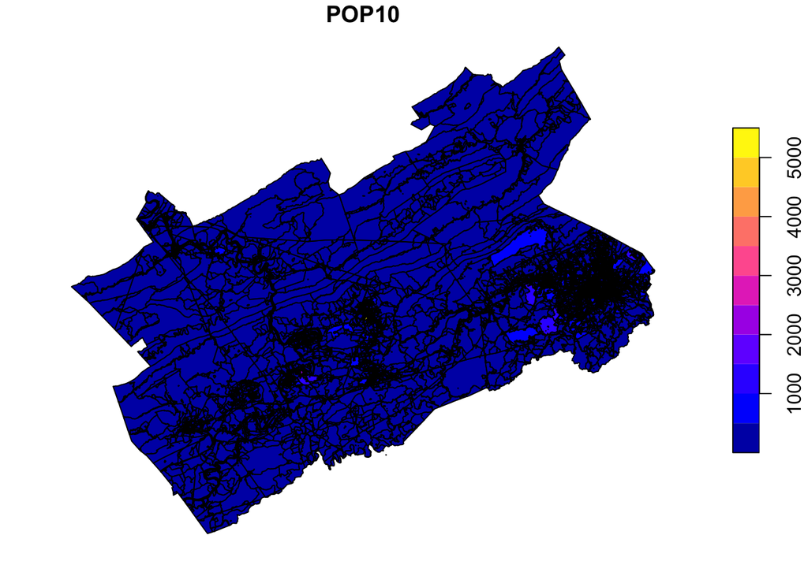

```r
plot(pophu["POP10"])
```

*Select a subset of pophu layer based on attributes*

Similar to select by attributes tool in ArcGIS, the following command selects features using POP10>100 criteria and save results to pophu_sub .

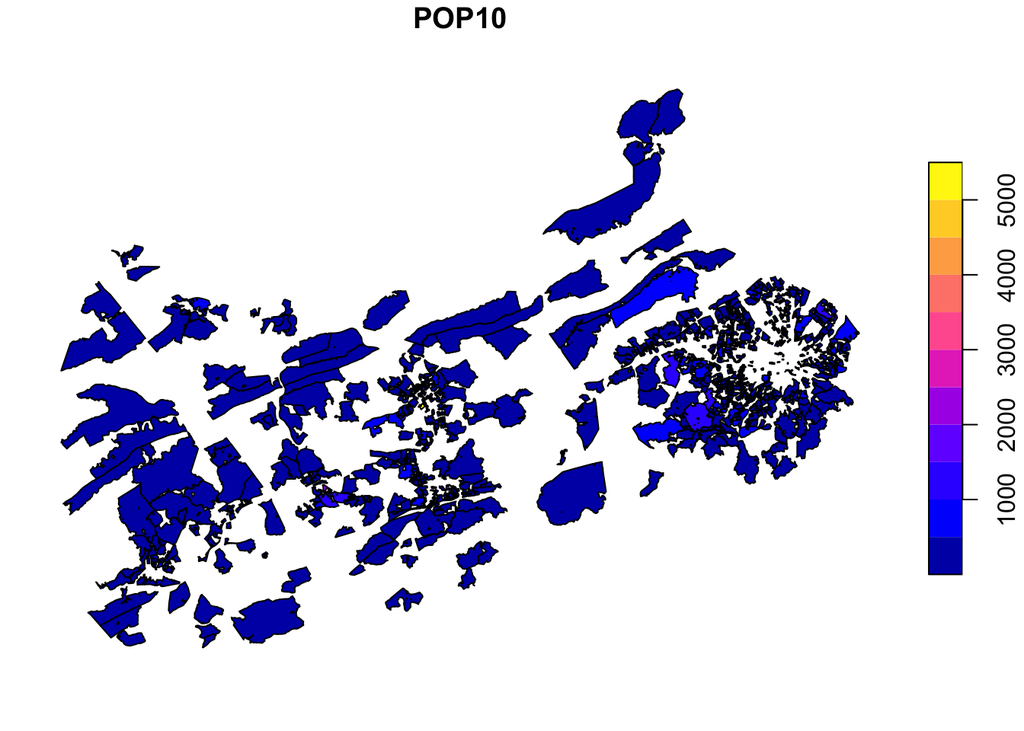

```r
pophu_sub <- pophu[pophu$POP10>100,]
plot(pophu_sub["POP10"])
```

*Use dplyr functions to handle data frame*

dplyr functions facilitate ‘tidy’ workflows that many find intuitive. RStudio, which support auto-completion of column names, makes it very appealing for interactive data analysis (https://r.geocompx.org). Below, we demonstrate several dplyr functions for subsetting data frames.

Use select() function to select columns by name.

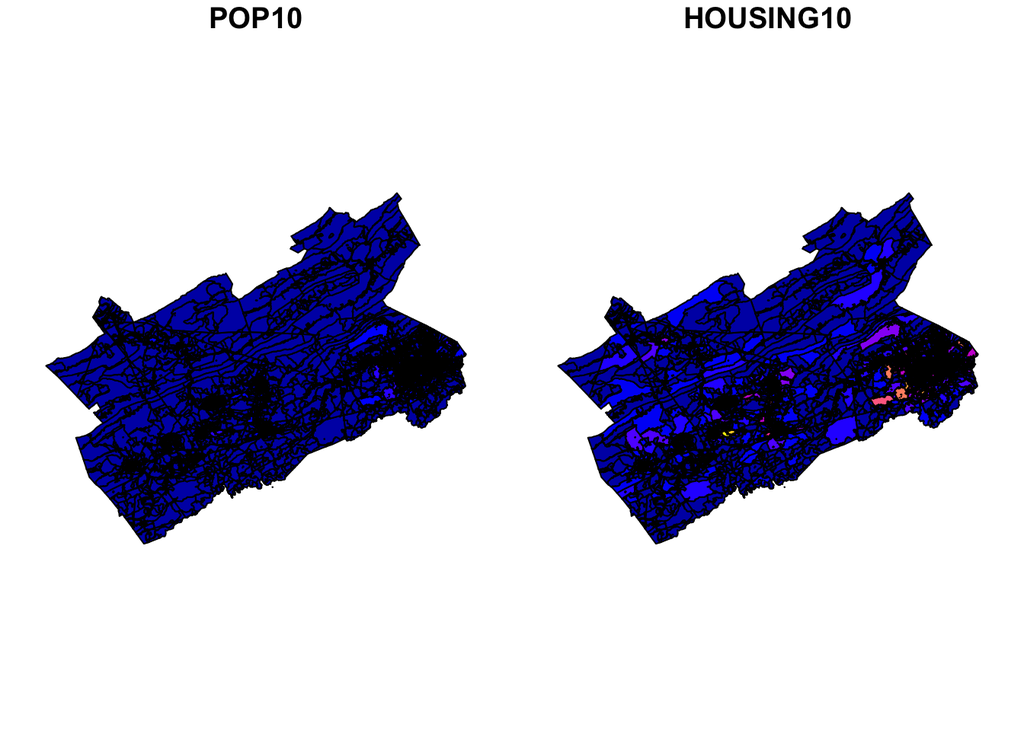

```r
pophu_sub<-select(pophu,POP10,HOUSING10)
plot(pophu_sub)
```

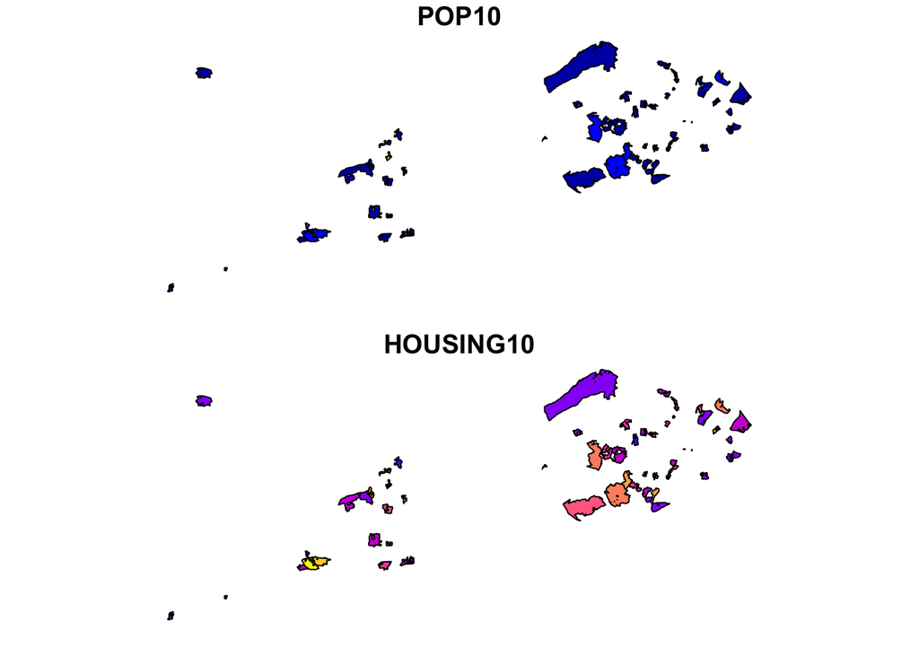

```r
a<-filter(pophu_sub,POP10>500)
plot(a)
```

Use a logical operator & (and) to combine two evaluation criteria

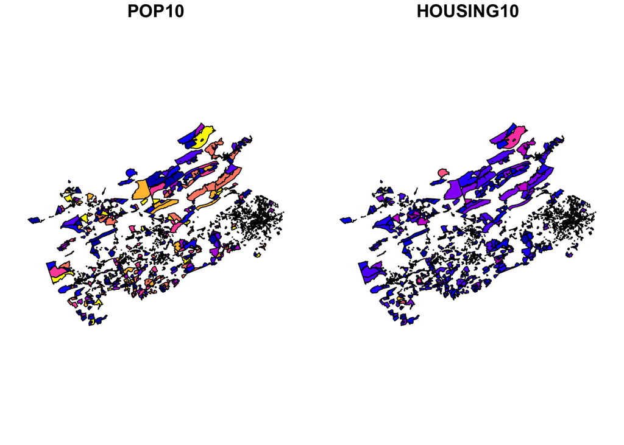

```r
a<-filter(pophu_sub,POP10>10&POP10<50)
plot(a)
```

The ‘pipe’ operator %>% allow us to stack dplyr functions. Specifically, the output of a previous function becomes the input of the next function. In the following example, we first use select() function to select ‘POP10’ and ‘HOUSING10’ variables from pophu data frame, the resultant data frame is further processed using filter() function.

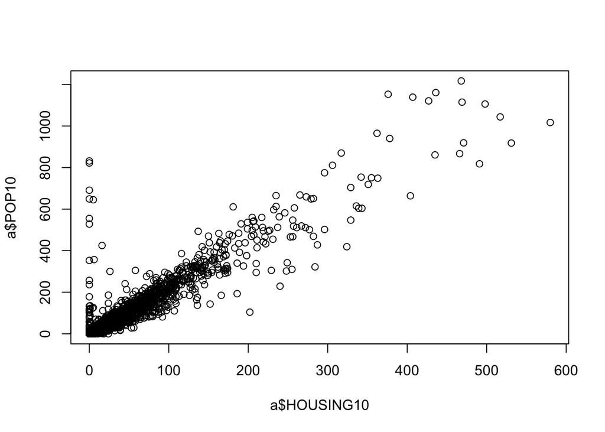

```r
a<-pophu %>%
  select(POP10,HOUSING10) %>%
  filter(POP10<2000)
plot(a$HOUSING10,a$POP10)
```